# Neural Network MARS Applicated on simulated data

References :

Article [1] (English) : Adaptive splines-based logistic regression with a ReLU neural network, Marie Guyomard, Susana Barbosa, Lionel Fillatre, JOBIM, 2022. ⟨hal-03778323⟩

Article [2] (French) : Régression logistique à base de splines adaptatives avec un réseau de neurones ReLU, Marie Guyomard, Susana Barbosa, Lionel Fillatre, GRETZSI, 2022. ⟨hal-03778328⟩

## NN-MARS Model

The above algorithm is available here for **binary** classification problems.

Let suppose we have $N$ independant and identically distributed pairs $\{x^{(i)}, y^{(i)}\}_{i=1}^{N}$. We consider the following neural network :

$$f(x) = \hat{\mathbb{P}}\left(Y=1|X\right) = \sigma(\psi_X(\theta)).$$

with

$$\sigma = \frac{1}{1+\exp(-X)} $$

and $$\psi_X(\theta) = \beta_0 + \beta \phi\left(\bar{W}X^T+b\right).$$

such as

$\phi(X) = \text{ReLU}(X) = \max\{0,X\} \\ X \in\mathbb{R}^{N \times d} \\ b = [b_{11}, b_{12}, \dots, b_{d1}, b_{d2}]^T \in \mathbb{R}^{2d} \\ \beta = [\beta_{11}, \beta_{12}, \dots, \beta_{d1}, \beta_{d2}] \in \mathbb{R}^{2d} \\ \bar{W} = \begin{bmatrix} -1 & 0 & \dots & 0 \\ 1 & 0 & \dots & 0 \\ 0 & -1 & \dots & 0 \\ 0 & 1 & \dots & 0 \\ \end{bmatrix} \in \mathbb{R}^{2d \times d} \\ \theta = [\beta_0, \beta, b^T]^T = [\beta_0, \beta_1, \dots, \beta_d, b_1, \dots, b_p]^T $

*Remark : for binar categorical variable, only one node is created.*

**Scheme of the model**

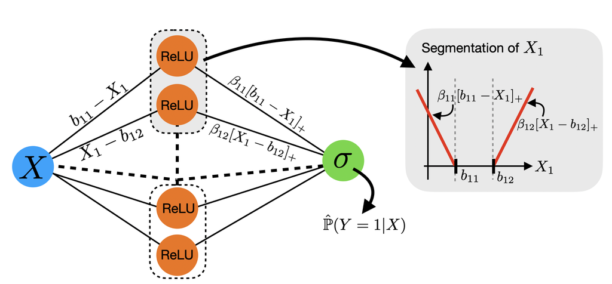

```python
from IPython import display
display.Image('Schema_NNMARS.png', width=1000)
```

Import of functions needed

```python
from NNMARS_Functions import *
# run NNMARS_Functions.ipynb
```

## Simulated Data

We simulated $x \in \mathbb{R}^2$ data in order to visualize the estimated decision boundaries.

We seek to predict the probability of developing a pathology as a function of cholesterol level ($X_1$) and weight ($X_2$). Both variables are simulated according to normal distributions, in order to consider normalized data. The labels were constructed as follow :

- When the cholesterol level is low, the patient is more protected against the disease ($\beta_{11} = -2$). On the other hand, when it is high, the patient is more at risk ($\beta_{12}=4$).
- Being underweight or overweight increases the probability of developing the pathology (respectively $\beta_{21}=1.5$ and $\beta_{22}=3$).

Since in real applications the boundary is noisy, we define the labels using a Bernouilli distribution with the estimated probability of developing the disease as parameter.

```python
np.random.seed(407)

# Features
data = pd.DataFrame({'X1':np.random.randn(5000), 'X2':np.random.randn(5000)})

beta_0, beta_11, beta_12, beta_21, beta_22 = 0, -2, 4, 1.5, 3
t11, t12, t21, t22 = 0, 1, -1, 1

# Labels
label = []
for i in range(data.shape[0]):
    score_i=beta_0
    if data.loc[i, 'X1']<=t11:
        score_i += beta_12 * (t11-data.loc[i, 'X1'])
    if data.loc[i, 'X1']>=t12:
        score_i += beta_11 * (data.loc[i, 'X1']-t12)
    if data.loc[i, 'X2'] <= t21:
        score_i += beta_21 * (t21-data.loc[i, 'X2'])
    if data.loc[i, 'X2'] >= t22:
        score_i += beta_22 * (data.loc[i, 'X2']-t22)

    proba_i = 1/(1+math.exp(score_i))
    label.append(np.random.binomial(n = 1, p = proba_i, size = 1)[0])

data['label']=label
X = data[['X1', 'X2']]
```

```python
data.info()
```

```
<class 'pandas.core.frame.DataFrame'>
RangeIndex: 5000 entries, 0 to 4999
Data columns (total 3 columns):
 #   Column  Non-Null Count  Dtype
---  ------  --------------  -----
 0   X1      5000 non-null   float64
 1   X2      5000 non-null   float64
 2   label   5000 non-null   int64
dtypes: float64(2), int64(1)
memory usage: 117.3 KB
```

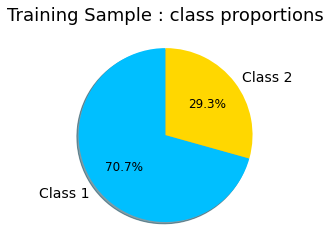

```python
fig = plt.figure()
patches, texts, autotexts = plt.pie(data.label.value_counts(), autopct='%1.1f%%',
                    shadow=True, startangle=90, labels=['Class 1','Class 2'],
                  colors=['deepskyblue','gold'])

plt.title("Training Sample : class proportions",size=18)
texts[0].set_fontsize(14)
texts[1].set_fontsize(14)
for autotext in autotexts:
    autotext.set_fontsize(12)
plt.show()
```

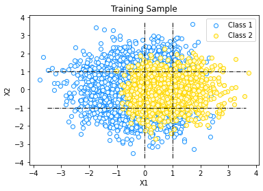

```python
plt.scatter(data.loc[np.where(np.array(data.label)==0)[0], 'X1'], data.loc[np.where(np.array(data.label)==0)[0], 'X2'], edgecolor='dodgerblue', color='azure')
plt.scatter(data.loc[np.where(np.array(data.label)==1)[0], 'X1'], data.loc[np.where(np.array(data.label)==1)[0], 'X2'], edgecolor='gold', color='lemonchiffon')
plt.xlabel('X1')
plt.ylabel('X2')
plt.title("Training Sample")
plt.legend(['Class 1', 'Class 2'])
plt.vlines(t11, data['X1'].min(), data['X1'].max(), ls='-.', lw=1, color='black')
plt.vlines(t12, data['X1'].min(), data['X1'].max(), ls='-.', lw=1, color='black')
plt.hlines(t21, data['X2'].min(), data['X2'].max(), ls='-.', lw=1, color='black')
plt.hlines(t22, data['X2'].min(), data['X2'].max(), ls='-.', lw=1, color='black')
```

We decide to rebalance the dataset

```python
index_1 = random.sample(np.where(pd.DataFrame(label)==0)[0].tolist(), 1000)
index_2 = random.sample(np.where(pd.DataFrame(label)==1)[0].tolist(), 1000)

data_balanced = data.iloc[index_1+index_2,:]
data_balanced = data_balanced.reset_index()
data_balanced.drop(['index'], axis='columns', inplace=True)

X_balanced = data_balanced[['X1', 'X2']]
```

```python
data_balanced.info()
```

```
<class 'pandas.core.frame.DataFrame'>
RangeIndex: 2000 entries, 0 to 1999
Data columns (total 3 columns):
 #   Column  Non-Null Count  Dtype
---  ------  --------------  -----
 0   X1      2000 non-null   float64
 1   X2      2000 non-null   float64
 2   label   2000 non-null   int64
dtypes: float64(2), int64(1)
memory usage: 47.0 KB
```

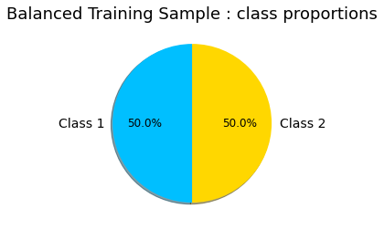

```python
fig = plt.figure()
patches, texts, autotexts = plt.pie(data_balanced.label.value_counts(), autopct='%1.1f%%',
                    shadow=True, startangle=90, labels=['Class 1','Class 2'],
                  colors=['deepskyblue','gold'])

plt.title("Balanced Training Sample : class proportions",size=18)
texts[0].set_fontsize(14)
texts[1].set_fontsize(14)
for autotext in autotexts:
    autotext.set_fontsize(12)
plt.show()
```

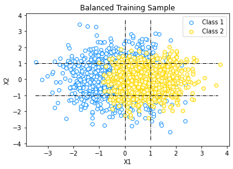

```python
plt.scatter(data_balanced.loc[np.where(np.array(data_balanced.label)==0)[0], 'X1'], data_balanced.loc[np.where(np.array(data_balanced.label)==0)[0], 'X2'], edgecolor='dodgerblue', color='azure')
plt.scatter(data_balanced.loc[np.where(np.array(data_balanced.label)==1)[0], 'X1'], data_balanced.loc[np.where(np.array(data_balanced.label)==1)[0], 'X2'], edgecolor='gold', color='lemonchiffon')
plt.xlabel('X1')
plt.ylabel('X2')
plt.title("Balanced Training Sample")
plt.legend(['Class 1', 'Class 2'])
plt.vlines(t11, data['X1'].min(), data['X1'].max(), ls='-.', lw=1, color='black')
plt.vlines(t12, data['X1'].min(), data['X1'].max(), ls='-.', lw=1, color='black')
plt.hlines(t21, data['X2'].min(), data['X2'].max(), ls='-.', lw=1, color='black')
plt.hlines(t22, data['X2'].min(), data['X2'].max(), ls='-.', lw=1, color='black')
```

# Replication of results of Articles [1] & [2]

For these results, we compute the NN-MARS on balanced dataset.

Parameters used :

```python
nb_folds = 5
epoch = 10000
learning_rate = 0.05
early_stopping = False
option_balanced = False
dropout_rate = 0
```

### Training

```
Performances par itération :
   acc_train  acc1_train  acc2_train  auc_train  acc_test  acc1_test  \
0   0.779286    0.702128    0.857554   0.851826  0.771667   0.718644
1   0.767857    0.683381    0.851852   0.842503  0.776667   0.688742
2   0.777143    0.685315    0.872993   0.852553  0.771667   0.684211
3   0.755714    0.670423    0.843478   0.834217  0.803333   0.724138
4   0.772143    0.674785    0.868946   0.840780  0.776667   0.695364

   acc2_test  auc_test
0   0.822951  0.830575
1   0.865772  0.837148
2   0.850794  0.833617
3   0.877419  0.855150
4   0.859060  0.846671
Performance moyenne :
acc_train     0.770429
acc1_train    0.683206
acc2_train    0.858965
auc_train     0.844376
acc_test      0.780000
acc1_test     0.702220
acc2_test     0.855199
auc_test      0.840632
dtype: float64
```

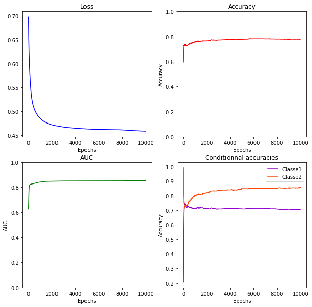

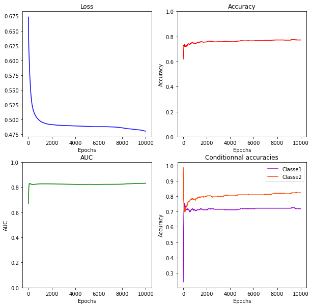

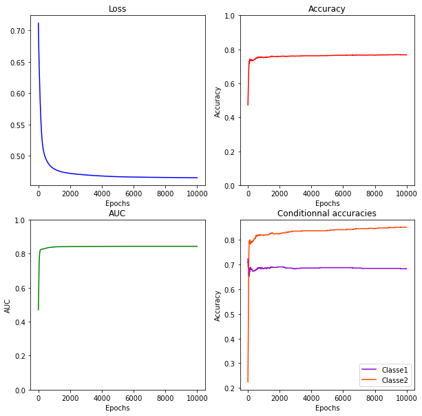

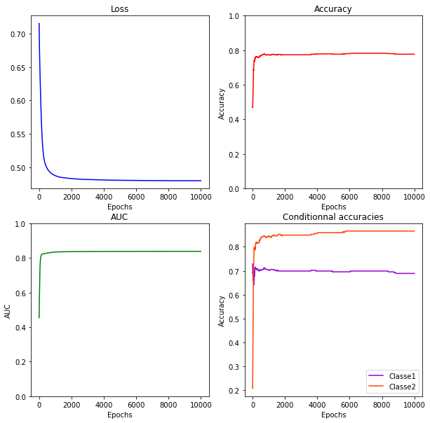

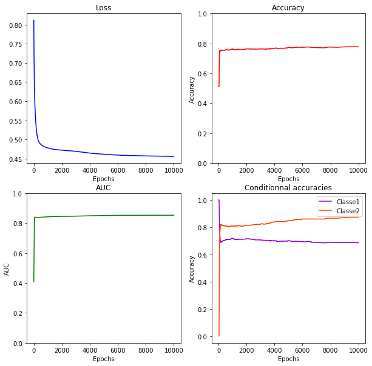

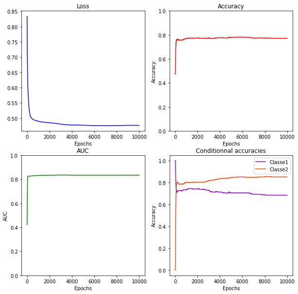

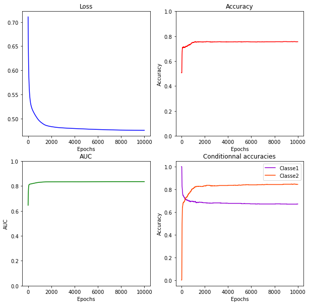

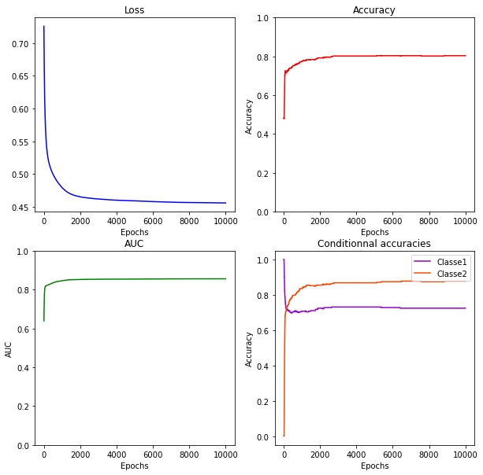

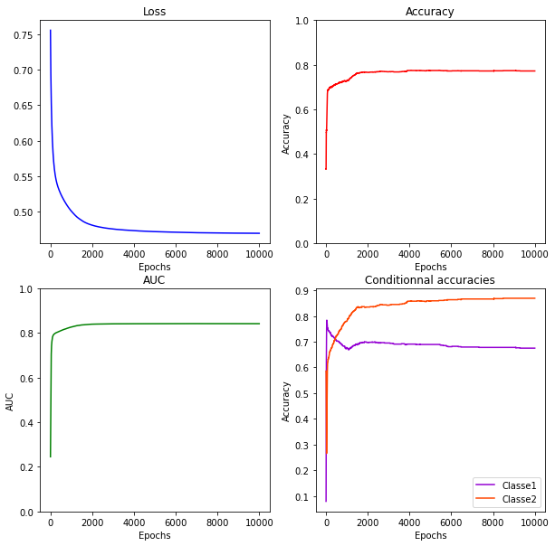

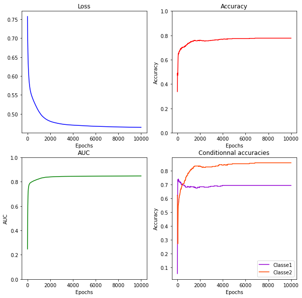

```python
np.random.seed(407)
res_iter, res_mean, res_std, times_fold, times, models_fold = NNMARS_CrossValidation(X_balanced, data_balanced.label, nb_folds, learning_rate, epoch, early_stopping, option_balanced, dropout_rate)
```

```python
print('Computation time per fold :' )
print(times_fold)

print('Mean computation time :')
print(times['mean'].values)
```

```
Computation time per fold :
[184.46723771095276, 184.1991958618164, 184.36493277549744, 183.6480484008789, 183.96504187583923]
Mean computation time :
[184.12889132]
```

## Accuracies

- Per iteration

```python
res_iter
```

|  | acc_train | acc1_train | acc2_train | auc_train | acc_test | acc1_test | acc2_test | auc_test |
| --- | --- | --- | --- | --- | --- | --- | --- | --- |
| 0 | 0.779286 | 0.702128 | 0.857554 | 0.851826 | 0.771667 | 0.718644 | 0.822951 | 0.830575 |
| 1 | 0.767857 | 0.683381 | 0.851852 | 0.842503 | 0.776667 | 0.688742 | 0.865772 | 0.837148 |
| 2 | 0.777143 | 0.685315 | 0.872993 | 0.852553 | 0.771667 | 0.684211 | 0.850794 | 0.833617 |
| 3 | 0.755714 | 0.670423 | 0.843478 | 0.834217 | 0.803333 | 0.724138 | 0.877419 | 0.855150 |
| 4 | 0.772143 | 0.674785 | 0.868946 | 0.840780 | 0.776667 | 0.695364 | 0.859060 | 0.846671 |

- Mean

```python
res_mean
```

```
acc_train     0.770429
acc1_train    0.683206
acc2_train    0.858965
auc_train     0.844376
acc_test      0.780000
acc1_test     0.702220
acc2_test     0.855199
auc_test      0.840632
dtype: float64
```

- std

```python
res_std
```

```
acc_train     0.009349
acc1_train    0.012215
acc2_train    0.012133
auc_train     0.007778
acc_test      0.013281
acc1_test     0.018050
acc2_test     0.020493
auc_test      0.010121
dtype: float64
```

### Plot estimated splines

We here plot the estimated splines by NN-MARS. To do so, we generate a sequence of data and apply the best estimated NN-MARS (the one who maximises the AUC on the test sample).

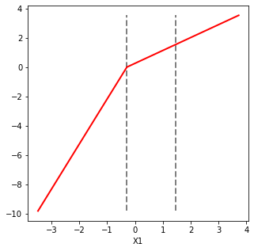

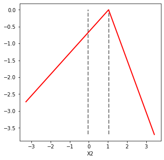

```python
NNMARS_plot_splines(X_balanced, models_fold[np.argmax(res_iter['auc_test'])], figsize=(5,5), Save_Fig=False, path=[])
```

### Plot boundary

We here plot the estimated boundary on the training set. To do so, we plot the simulated data. Then we generate a meshgrid and apply the best estimated NN-MARS (the one who maximises the AUC on the test sample). We then add on the plot, the boundaries estimated by the first layer (in black) and the final decision rule (in red).

Remarks : this method works for binary classification problem with only 2 features.

This method was inspired by the work of Randall Balestriero concerning the vizualisation of splines estimated in deep networks provided here : https://github.com/RandallBalestriero/spline-DN-visualization

MIT License - Copyright (c) 2021 BALESTRIERO Randall

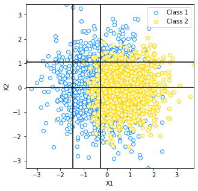

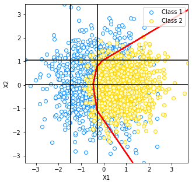

```python
outils_partition = Plot_partition_NN_MARS(data_balanced[['X1', 'X2']], np.array(data_balanced.label), models_fold[np.argmax(res_iter['auc_test'])])
meshgrid, Yhat_meshgrid = outils_partition.figure_partition()
```

# Application to imbalanced dataset

For this example, we use the reweighted binary cross entropy loss : $$L_{w} = \prod_{i=1}^{N} \hat{\mathbb{P}}\left(Y_i=1|X_i\right)^{w_1y_i} \times \left(1 - \hat{\mathbb{P}}\left(Y_i=1|X_i\right)\right)^{w_2(1-y_i)}.$$

with

$$w_k = \frac{N}{\sum_{i=1}^N \mathbb{1}_{\{Y_i=k\}}}.$$

```python
nb_folds = 5
epoch = 10000
learning_rate = 0.02
early_stopping = False
option_balanced = True
dropout_rate = 0
```

## Training

```
Performances par itération :
   acc_train  acc1_train  acc2_train  auc_train  acc_test  acc1_test  \
0   0.729429    0.688790    0.827017   0.837458  0.721333   0.681733
1   0.719143    0.665597    0.851889   0.833399  0.727333   0.668912
2   0.724286    0.676271    0.844156   0.836666  0.726667   0.672147
3   0.720286    0.673304    0.831569   0.829875  0.736000   0.692164
4   0.726286    0.684853    0.823755   0.832423  0.726667   0.688951

   acc2_test  auc_test
0   0.817352  0.824173
1   0.859002  0.841035
2   0.847639  0.832622
3   0.845794  0.844277
4   0.822695  0.837246
Performance moyenne :
acc_train     0.723886
acc1_train    0.677763
acc2_train    0.835677
auc_train     0.833964
acc_test      0.727600
acc1_test     0.680781
acc2_test     0.838497
auc_test      0.835871
dtype: float64
```

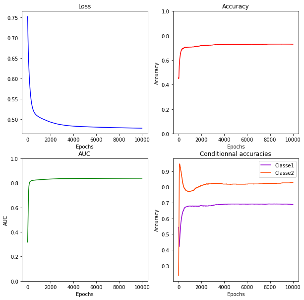

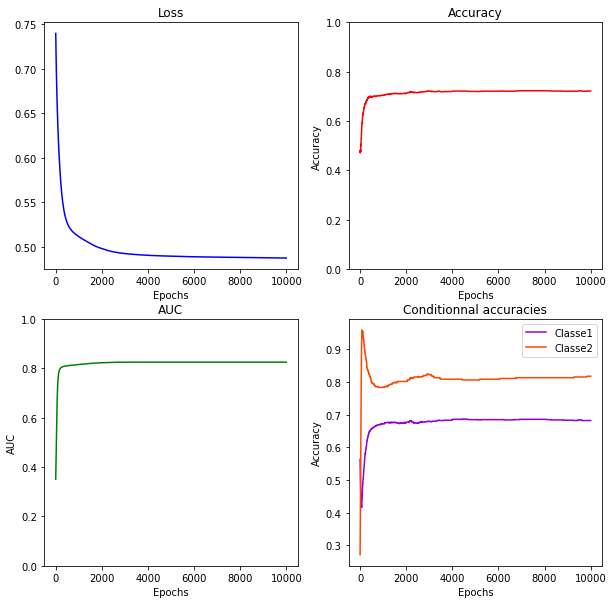

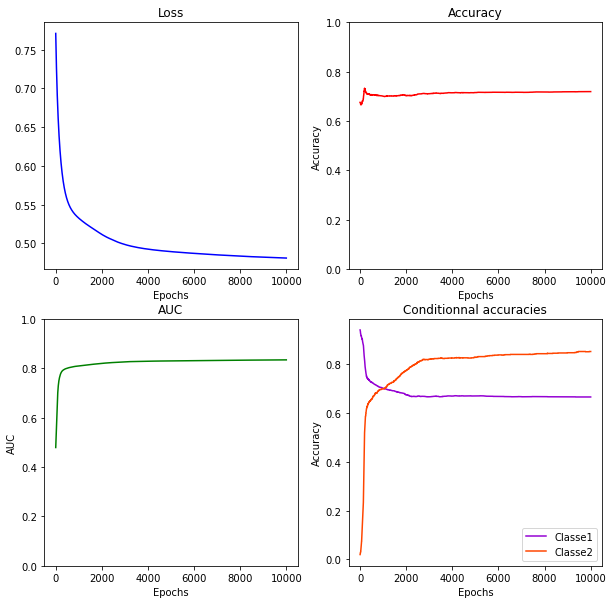

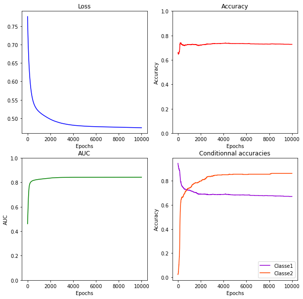

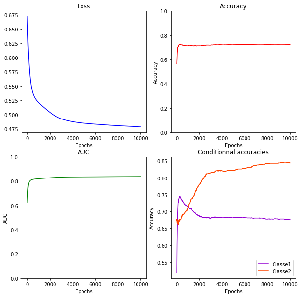

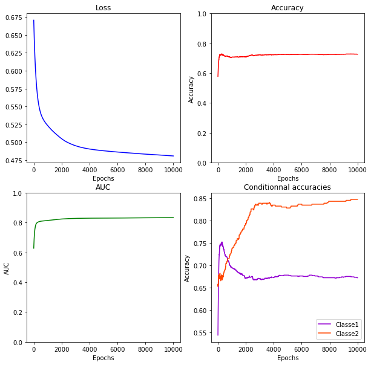

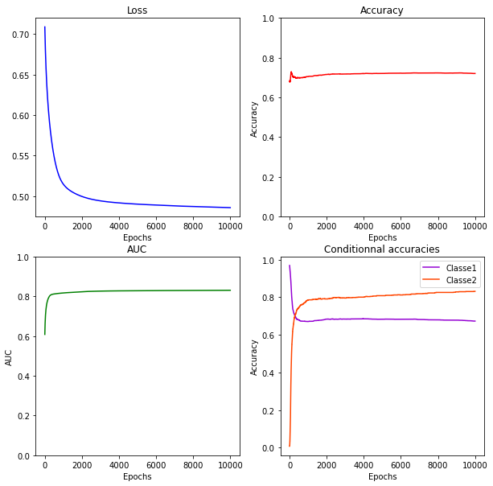

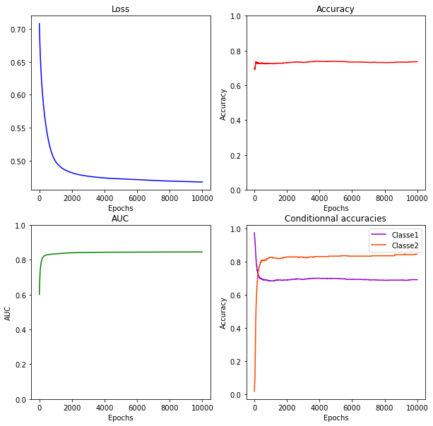

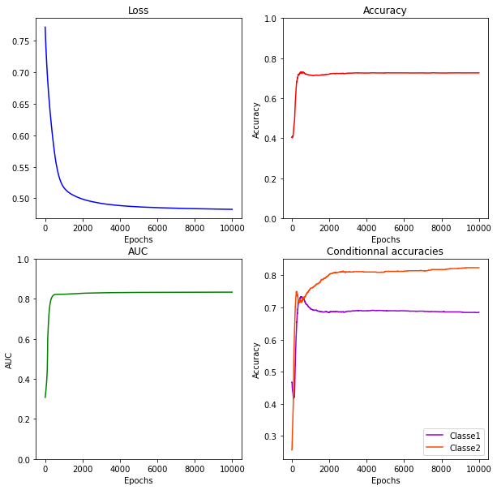

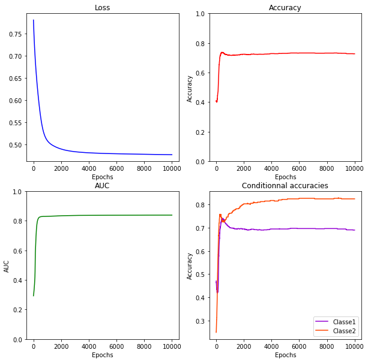

```python
np.random.seed(407)
res_iter_reweighted, res_mean_reweighted, res_std_reweighted, times_fold_reweighted, times_reweighted, models_fold_reweighted = NNMARS_CrossValidation(X, data.label, nb_folds, learning_rate, epoch, early_stopping, option_balanced, dropout_rate)
```

```python
print('Computation time per fold :' )
print(times_fold_reweighted)

print('Mean computation time :')
print(times_reweighted['mean'].values)
```

```
Computation time per fold :
[862.5451583862305, 1041.6228981018066, 941.6403839588165, 1179.5586104393005, 1258.3257005214691]
Mean computation time :
[1056.73855028]
```